# FIFA

Rieser Philipp

Leistungsnachweis für das Modul: Wahrscheinlichkeit und Statistik 1

22 Dezember 2017

In dieser Semesterarbeit wird die ewige Tabelle der FIFA Fusballweltmeiterschaften analysiert. Die Variablen Spiele, Punkte, Siege, Tordifferenz und Teilnahmen als Indikatoren für den Erfolg eines Landes an den Weltmeisterschaften sollen dabei unter die Lupe genommen werden.

## WM-Titel

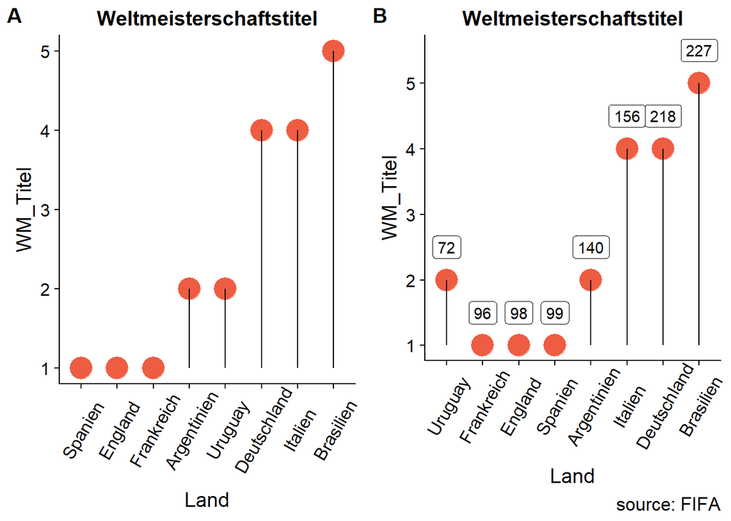

A: In diesem Lollipop-Plot sind alle Teams eingezeichnet die mindestens einmal die Weltmeisterschaft gewonnen haben. Es stellt sich die Frage, ob es auch andere Kriterien gäbe, um die verschiedenen Teams miteinander zu vergleichen. Gehen wir davon aus, dass ein Sieg an einem WM-Spiel 3 Punkte und ein Unentschieden 1 Punkt gibt.

B: Hier ist der gleiche Plot, sortiert nach den erreichten Punkten. Wenn wir von dieser Grafik ausgehen würden, könnte man sagen das Brasilien mit 227 Punkten und 5 WM-Titel das beste Team wäre. Aber man könnte auch die Punkte pro WM-Titel miteinander vergleichen. Uruguay hat mit 36 Punkten pro WM-Titel eine bessere Bilanz als Brasilien mit 45.4 Punkten pro WM-Titel.

Welches Team ist also das bessere?

## Korrelation

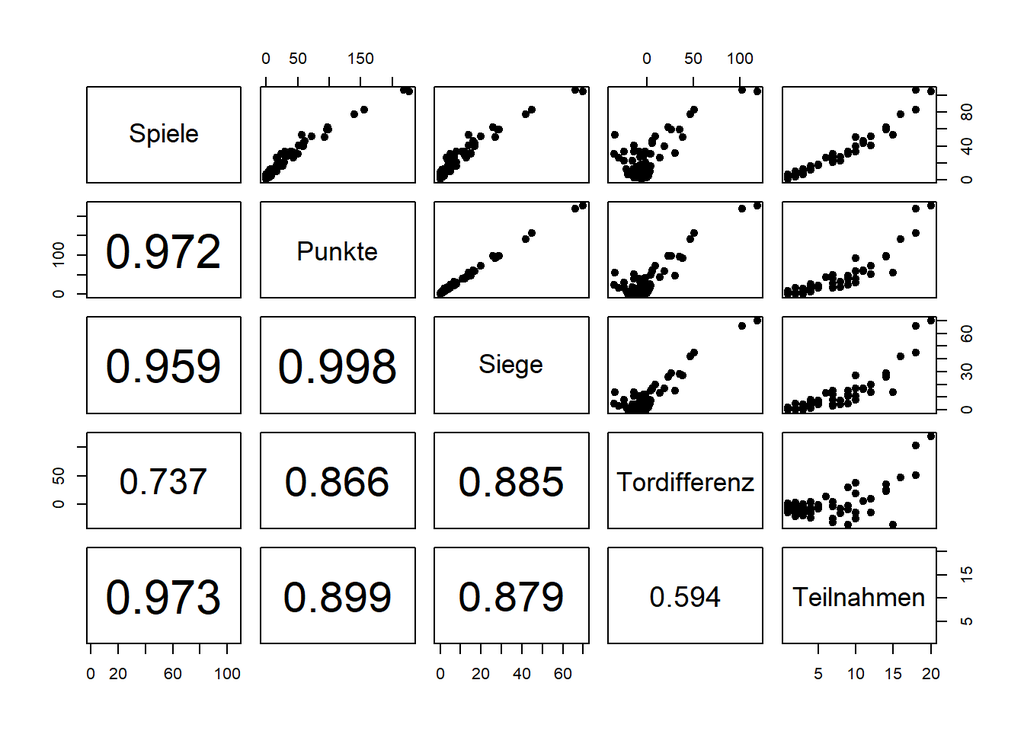

In dieser um die Pearson-Korellationskoeffizienten erweiterten Scatterplotmatrix wird ersichtlich, dass zwischen den untersuchten Variablen ein positiver, linearer Zusammenhang besteht. Die Korrelation ist dabei, bis auf Spiele-Tordifferenz und Tordifferenz-Teilnahme (mittel), stark.

## Das Beste Team

[interactive chart not shown]

Dieses Radarchart lässt viel Raum für Interpretationen. Es werden die 8 verschiedenen Weltmeisterteams und fünf Variablen dargestellt. Die einzelnen Weltmeister lassen sich ein- und ausblenden und erlauben somit einen direkten Vergleich miteinander. Die Daten wurden, um eine gemeinsame Darstellung zu ermöglichen, in relative Häufigkeiten umgewandelt.

Je grösser die Fläche desto “besser” ist das jeweilige Team. Je symmetrischer das Pentagon desto “ausgeglichener” ist das Team. Bei Brasilien und Deutschland erkennt man wie das Pentagon zur Variable Tordifferenz (geschossene Tore minus den kassierten Tore) ausreisst. Dies bedeutet das diese Teams in dieser Disziplin gut abschliessen. Uruguay hat eine eher schlechte Tordifferenz und dies führt zu einer “negativen” Verformung des Pentagons.

Die Verarbeitung von Daten auf diese Weise birgt aber einige Probleme. Es liessen sich unzählige weitere Variablen darstellen, diese würden die Figur noch weiter verkomplizieren.

## Fazit

Die Verarbeitung eines solchen Datensatzes birgt viele Probleme, es gibt viel Raum für Fehlinterpretationen. Den ersten Platz zu finden ist sehr schwierig. Es gäbe noch viele weitere Kriterien die eine Rolle spielen würden. Die Aufstellung eines Teams ist sehr subjektiv, einzelne Mannschaften sind einfach durch ihre “besseren” Spieler viel erfolgreicher als andere. Die kausalen Zusammenhänge werden im Datensatz nicht berücksichtigt.